# Introduction to ggplot2

M. Toomey

2022-10-02

### Components of a ggplot layer

1. data - a data frame or tibble
2. aesthetic mappings (aes) - specify the variables to be plotted
3. geom - specify the geometric to be drawn in the layer (e.g. points, lines, bars, etc.)
4. stat - compute and plot statisitcal transforms of the raw date
5. position - adjustments for overlapping elements
6. facet - generate multiple related plots

ggplots are layered compositions of these various components. To add components to the plot we simply add them with a “+”

### Template for ggplot components

```
p1 <- ggplot(data= <DATA>,mapping=aes(<MAPPINGS>) +
<GEOM_FUNCTION>(aes(<MAPPINGS>),
                stat=<STAT>,
                position=<POSITION>) +
                <COORDINATE_FUNCTION> +
                <FACET_FUNCTION>

print(p1)
ggsave(plot=p1, filename="MyPlot",width=5,height=3,units="in",device="svg")
```

### Packages

```r
library(tidyverse)
```

```r
library(ggplot2)
library(ggthemes) #extended themes for ggplot
library(patchwork) #tools for composing multiple panels
```

For these examples we will use the `mpg` built in data set from ggplot2

```r
?mpg
```

### Quick plotting for data exploration with `qplot`

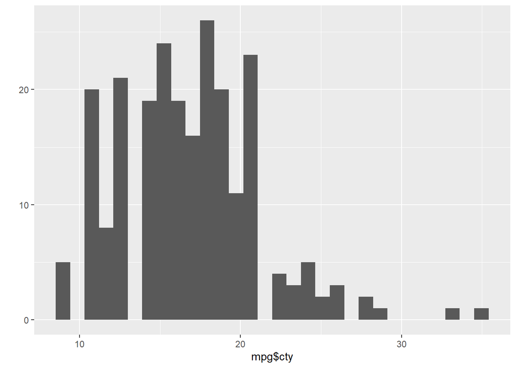

```r
# simple histogram
qplot(x=mpg$cty) #y-axis is count of observation with a given value of the x
```

We can modify the colors:

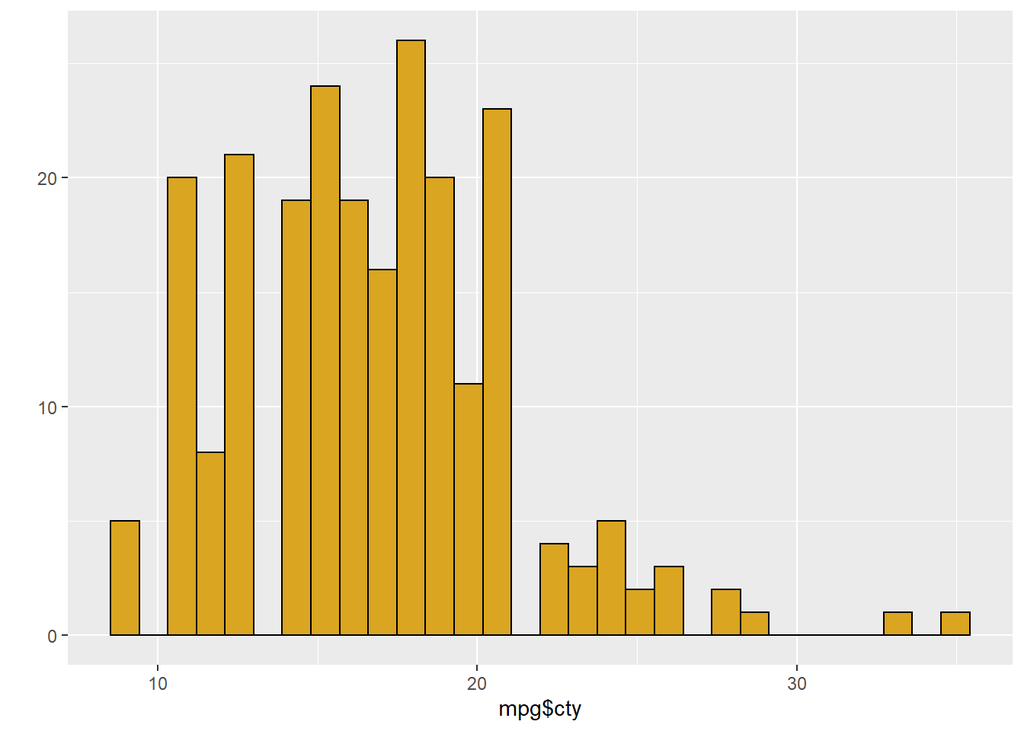

```r
qplot(x=mpg$cty,fill=I("goldenrod"),color=I("black"))
```

Here we used `I()` because if we directly call the color name, R will look for a variable with that name and attempt to apply colors based on the values of the variable.

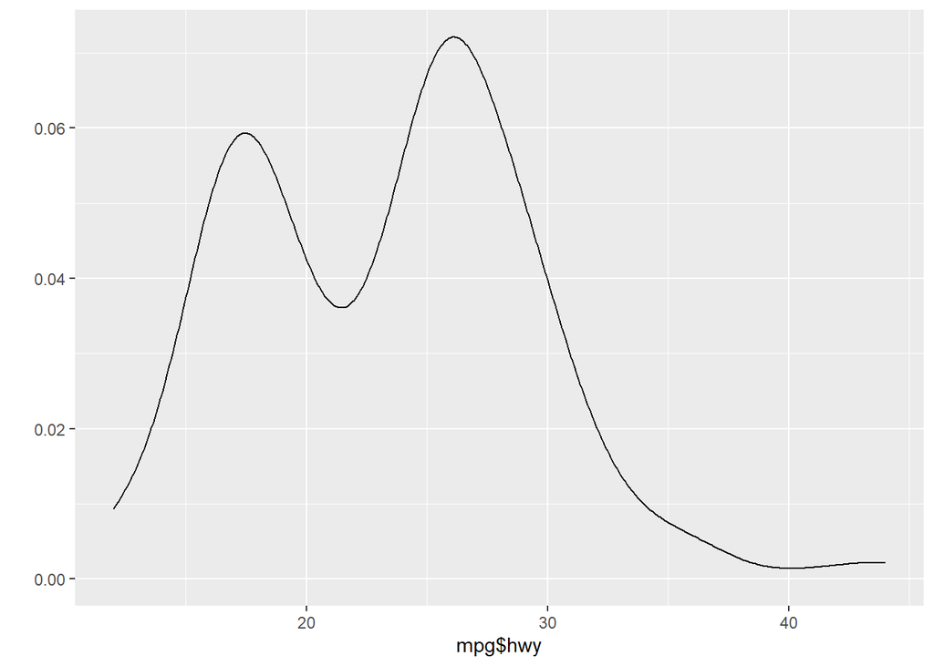

```r
# simple density plot
qplot(x=mpg$hwy,geom="density")
```

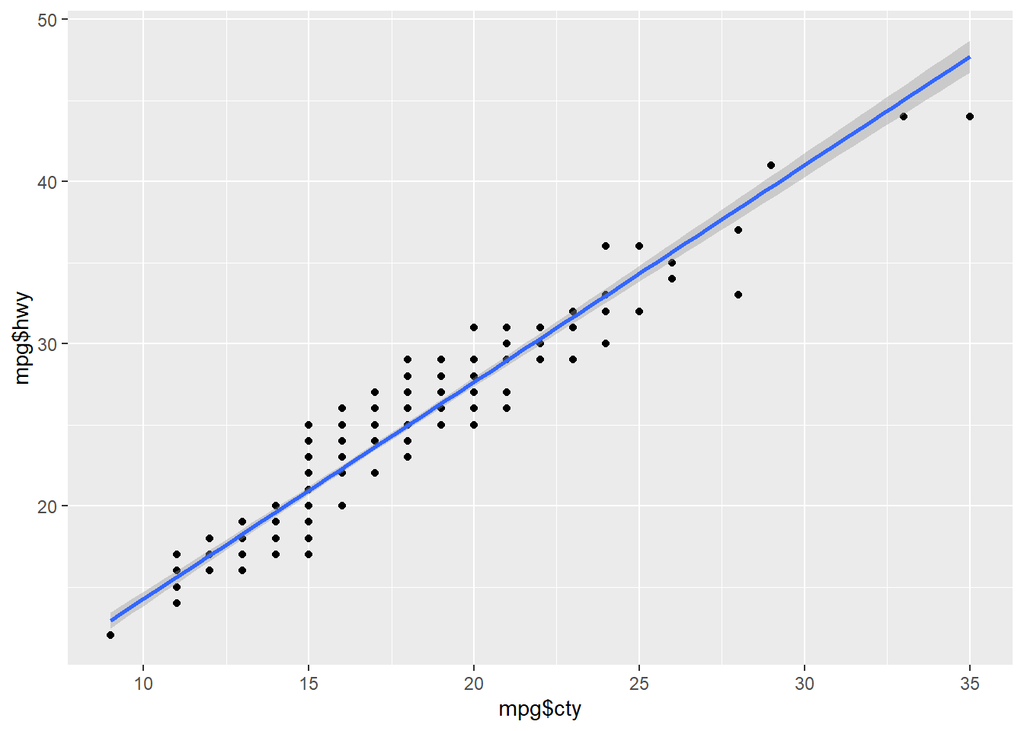

```r
# simple scatter plot with linear regression line
qplot(x=mpg$cty,y=mpg$hwy,geom=c("point","smooth"), method="lm")
```

We can color points by a variable

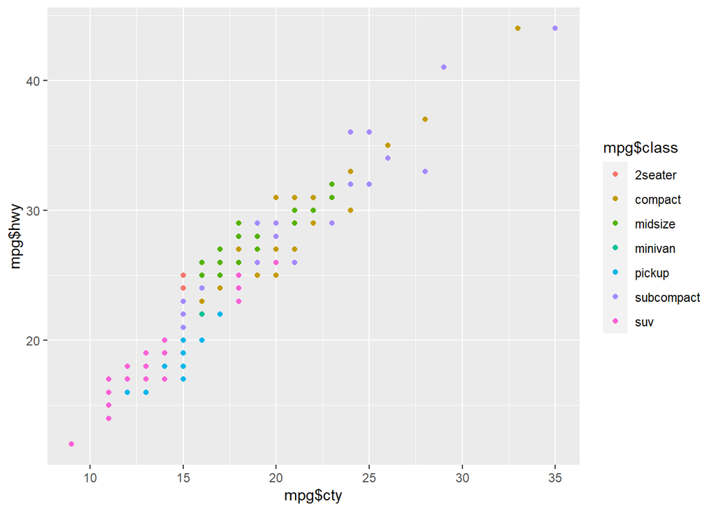

```r
qplot(x=mpg$cty,y=mpg$hwy, col = mpg$class, geom=c("point"))
```

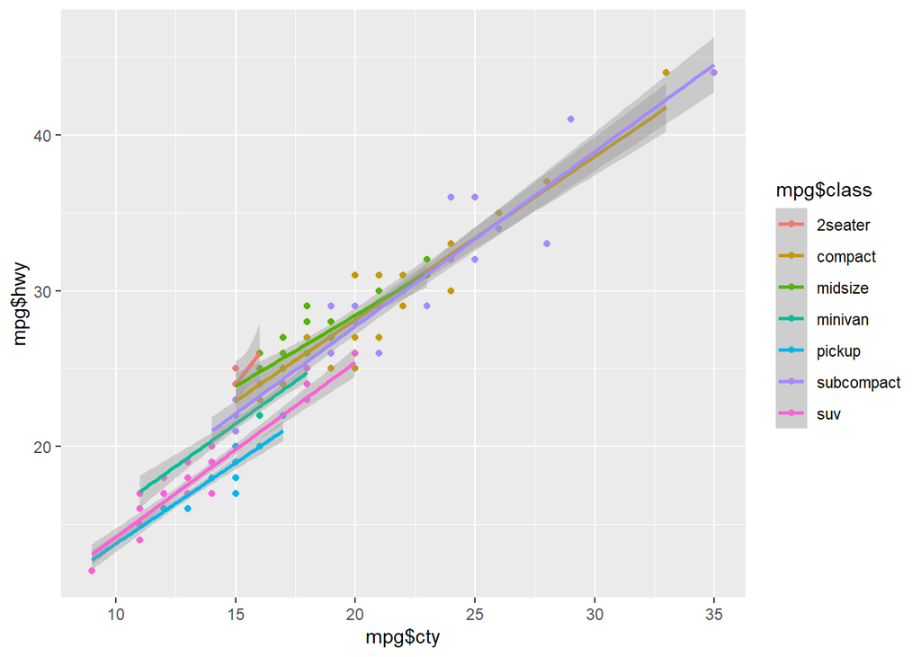

```r
# The regression is now applied to each class separately
qplot(x=mpg$cty,y=mpg$hwy, col = mpg$class, geom=c("point","smooth"), method="lm")
```

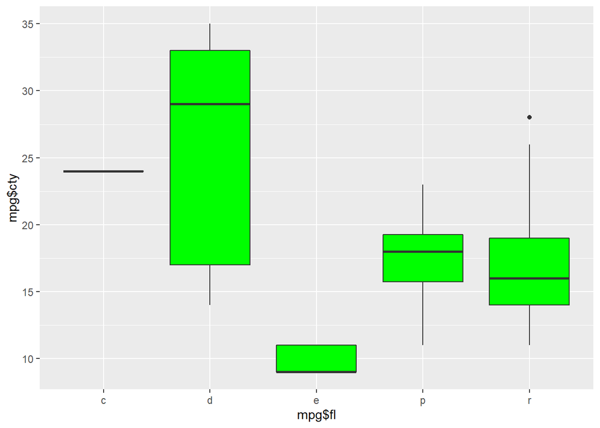

```r
# basic boxplot
qplot(x=mpg$fl, y=mpg$cty,geom="boxplot",fill=I("green"))
```

Interpretation:

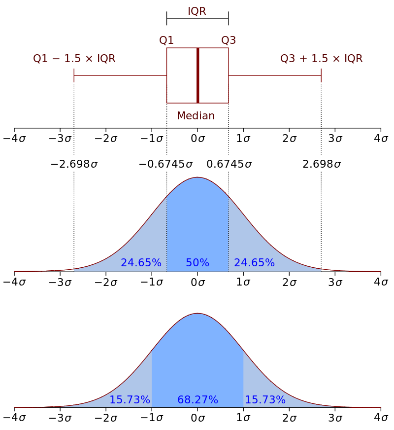

Interquartile range (IQR)

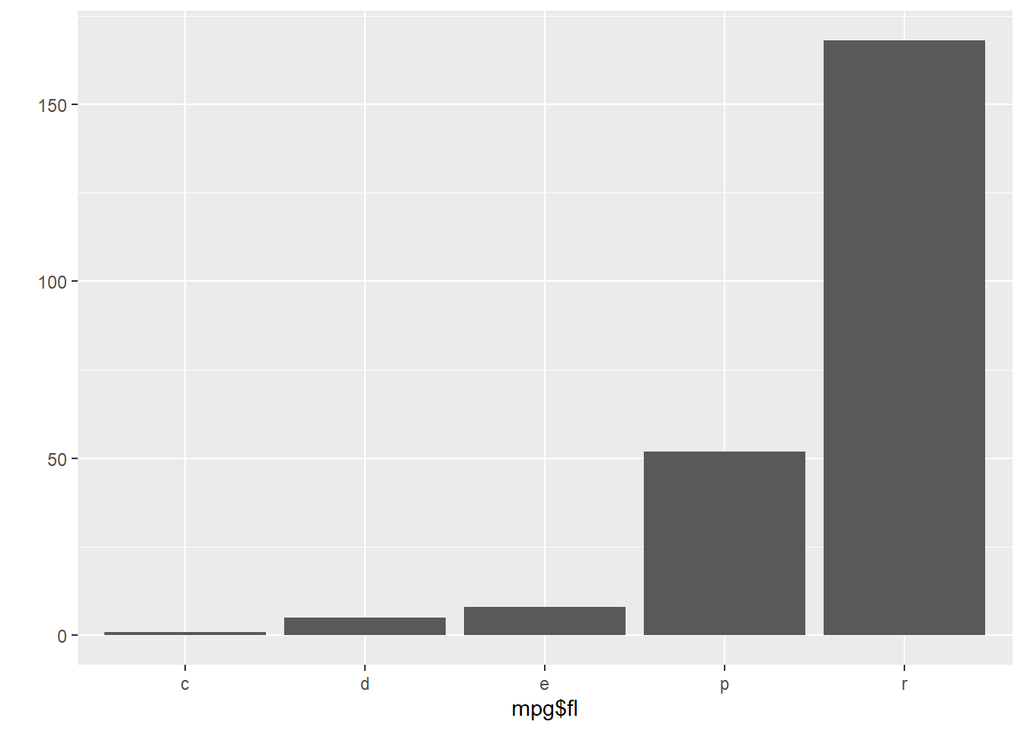

```r
# simple barplot
qplot(x=mpg$fl,geom="bar")
```

Most often bar charts are used to display summary values by group. One way to do this is to use `dplyr` to calculate summary stats and plot those with `col`

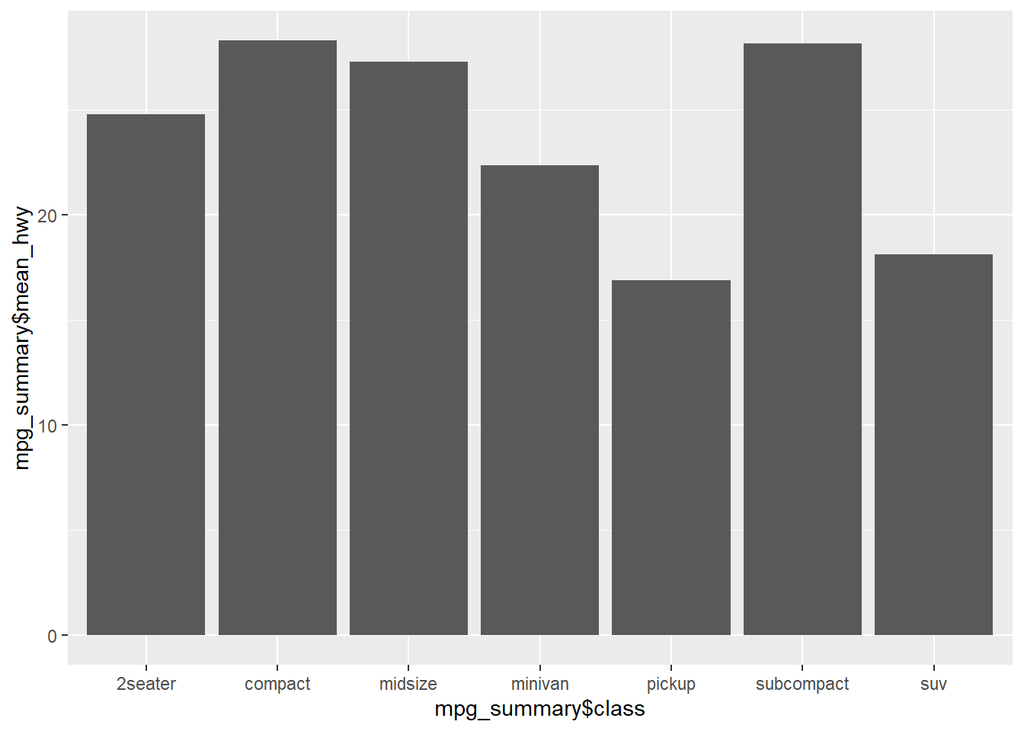

```r
# bar plot with specified means

mpg_summary<-mpg %>%
  group_by(class) %>%
  summarise(mean_hwy = mean(hwy))

p<-qplot(x=mpg_summary$class, y=mpg_summary$mean_hwy, geom="col")

p
```

We can flip this plot by layering `coord_flip`:

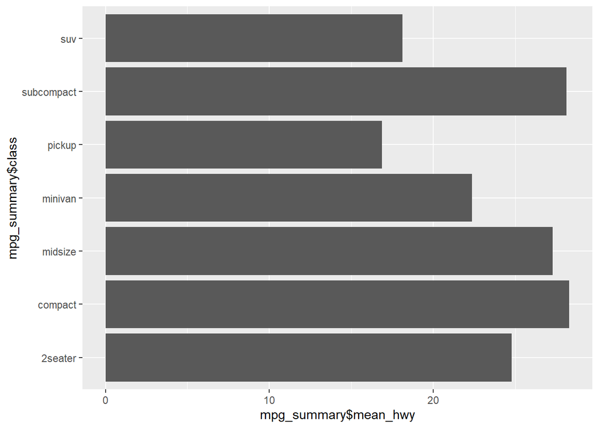

```r
p + coord_flip()
```